# Lab Assignment 11: Data Visualizations

## DS 6001: Practice and Application of Data Science

## H. Diana McSpadden (hdm5s)

### Instructions

Please answer the following questions as completely as possible using text, code, and the results of code as needed. Format your answers in a Jupyter notebook. To receive full credit, make sure you address every part of the problem, and make sure your document is formatted in a clean and professional way.

## Problem 0

Import the following libraries:

```python
import numpy as np
import pandas as pd
from matplotlib import pyplot as plt
import seaborn as sns
```

## Problem 1

Write a short paragraph that provides a critique of the following data visualizations. What's good about each figure, and what's not good? Pay particular attention to how well the figure communicates information to a general audience and tells a complete story. Make specific references to the ideas discussed in the first section of the Module 11 Jupyter notebook.

### Part a

[figure not shown]

[1 point]

#### Answer Problem 1 Part a

What is good is that the order, from left to right, is in an ordinal order from very concerned to not at all concerned. Everything else about this plot bothers me. The relative bar heights do not represent realtive differences in the values. In other words, this breaks the **principle of proportional ink**. I don't believe the heights of the bars and the overall height of the bar area are in any way related. There are no counts for how many people were surveyed and no information is provided about whether the sample is representative of a particular population. The plot below corrects one of these issues, the relative bar height.

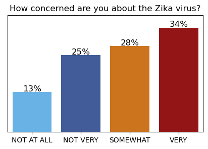

```python
zika_df = pd.DataFrame([['13','25','28','34']],columns=['NOT AT ALL','NOT VERY','SOMEWHAT','VERY'])

plt.figure(figsize=(5,3))
plt.title('How concerned are you about the Zika virus?')
# make a bar plot with the height being the value of the column and the x labels being the column names have the color based on the value of the column
sns.barplot(data=[['13'],['25'],['28'],['34']], palette=['#54B5FB','#3257A8','#E87200','#A80000'])
# set the x tick labels to the column names
plt.xticks([0,1,2,3],['NOT AT ALL','NOT VERY','SOMEWHAT','VERY'])
# put the label on top of the bar for the measure
for i in range(4):
    plt.text(i, int(zika_df.iloc[0,i]) + 0.2, str(zika_df.iloc[0,i]) + '%', ha='center', color='black', fontsize=12)

# don't show the y axis ticks
plt.yticks([])
# set the y range to 0 to 38
plt.ylim(0,38)
plt.show()
```

### Part b

[figure not shown]

[1 point]

#### Answer Problem 1 Part b

What is good is that the sections of the pie chart are well labeled. Everything else bothers me. This plot has the Darrell Hull "One Dimensional graph" problem, or it breaks the **principle of proportional ink**. The 3D pie chart distorts the proportionality of the areas. This is very obvious with the difference in the Production vs. Other. Production is 7.2% and Other is 34.6%. This should only be a difference of 1:4.8 or 1:5 ink. That sliver of Production does not look like one-fifth of Other.

### Part c

[figure not shown]

[1 point]

#### Answer Problem 1 Part c

This plot took a minute for me to even comprehend. The y axis is flipped bottom-to-top from increased to decreasing. I think this was an aesthetic choice to evoke dripping blood; however it makes the **increase** in murders committed using firearms harder to correlated with the enactment with Florida's 'Stand Your Ground' law, which is what the infographic is attempting to convey. I also find the x axis labels with the 1990s and 2000s decades and then the 2010s, that include two data points for 2011 and 2012 (if I am counting the data point correctly), confusing.

## Problem 2

For the rest of this lab, we will once again be working with the 2019 General Social Survey.

```python
%%capture
gss = pd.read_csv("https://github.com/jkropko/DS-6001/raw/master/localdata/gss2018.csv",
                 encoding='cp1252', na_values=['IAP','IAP,DK,NA,uncodeable', 'NOT SURE',
                                               'DK', 'IAP, DK, NA, uncodeable', '.a', "CAN'T CHOOSE"])
```

Here is code that cleans the data and gets it ready to be used for data visualizations:

```python
mycols = ['id', 'wtss', 'sex', 'educ', 'region', 'age', 'coninc',
          'prestg10', 'mapres10', 'papres10', 'sei10', 'satjob',
          'fechld', 'fefam', 'fepol', 'fepresch', 'meovrwrk']
gss_clean = gss[mycols]
gss_clean = gss_clean.rename({'wtss':'weight',
                              'educ':'education',
                              'coninc':'income',
                              'prestg10':'job_prestige',
                              'mapres10':'mother_job_prestige',
                              'papres10':'father_job_prestige',
                              'sei10':'socioeconomic_index',
                              'fechld':'relationship',
                              'fefam':'male_breadwinner',
                              'fehire':'hire_women',
                              'fejobaff':'preference_hire_women',
                              'fepol':'men_bettersuited',
                              'fepresch':'child_suffer',
                              'meovrwrk':'men_overwork'},axis=1)
gss_clean.age = gss_clean.age.replace({'89 or older':'89'})
gss_clean.age = gss_clean.age.astype('float')
```

The `gss_clean` dataframe now contains the following features:

- `id` - a numeric unique ID for each person who responded to the survey
- `weight` - survey sample weights
- `sex` - male or female
- `education` - years of formal education
- `region` - region of the country where the respondent lives
- `age` - age
- `income` - the respondent's personal annual income
- `job_prestige` - the respondent's occupational prestige score, as measured by the GSS using the methodology described above
- `mother_job_prestige` - the respondent's mother's occupational prestige score, as measured by the GSS using the methodology described above
- `father_job_prestige` -the respondent's father's occupational prestige score, as measured by the GSS using the methodology described above
- `socioeconomic_index` - an index measuring the respondent's socioeconomic status
- `satjob` - responses to "On the whole, how satisfied are you with the work you do?"
- `relationship` - agree or disagree with: "A working mother can establish just as warm and secure a relationship with her children as a mother who does not work."
- `male_breadwinner` - agree or disagree with: "It is much better for everyone involved if the man is the achiever outside the home and the woman takes care of the home and family."
- `men_bettersuited` - agree or disagree with: "Most men are better suited emotionally for politics than are most women."
- `child_suffer` - agree or disagree with: "A preschool child is likely to suffer if his or her mother works."
- `men_overwork` - agree or disagree with: "Family life often suffers because men concentrate too much on their work."

### Part a

Reorder the categories of `relationship` to "strongly agree", "agree", "disagree", and "strongly disagree".

Then create a simple barplot that shows the frequencies of the categories of `relationship` three times:

- once using `matplotlib` alone,
- once using `seaborn`,
- and once using the `.plot()` method from `pandas`.

Make sure each barplot has descriptive axis labels and a title, and set a good size for each figure displayed in the Jupyter notebook. [2 points]

```python
#gss_clean['relationship'].unique()
gss_clean['relationship'] = gss_clean.relationship.astype('category')


gss_clean['relationship'] = pd.Categorical(gss_clean.relationship.astype('category'),
                      categories=["strongly agree","agree","disagree","strongly disagree"],
                      ordered=True)
```

```python
mybars_relationship = gss_clean['relationship'].value_counts().sort_index()
mybars_relationship
```

```
strongly agree       480
agree                670
disagree             324
strongly disagree     76
Name: relationship, dtype: int64
```

**First, Matplotlib**

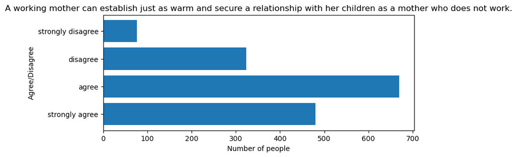

```python
plt.figure(figsize=(8, 3))
plt.barh(mybars_relationship.index, mybars_relationship.values)
plt.ylabel('Agree/Disagree')
plt.xlabel('Number of people')
plt.title('A working mother can establish just as warm and secure a relationship with her children as a mother who does not work.')
```

**Second, Seaborn**

```python
mybars_relationship_df = mybars_relationship.reset_index()
mybars_relationship_df
```

|  | index | relationship |
| --- | --- | --- |
| 0 | strongly agree | 480 |
| 1 | agree | 670 |
| 2 | disagree | 324 |
| 3 | strongly disagree | 76 |

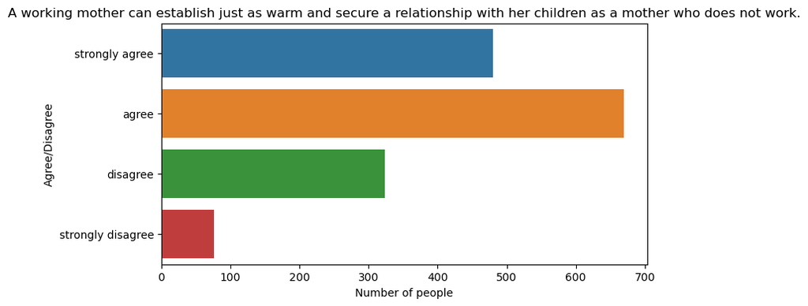

```python
plt.figure(figsize=(8, 4))
sns.barplot(x='relationship', y='index', data=mybars_relationship_df)
plt.ylabel('Agree/Disagree')
plt.xlabel('Number of people')
plt.title('A working mother can establish just as warm and secure a relationship with her children as a mother who does not work.')
```

**Third, with `plot()`**

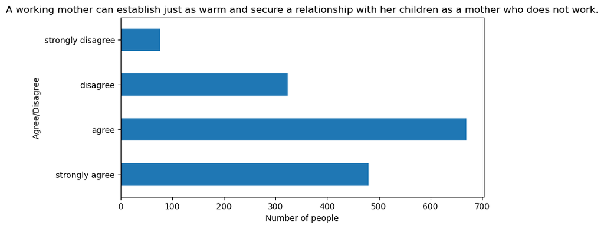

```python
mybars_relationship_df.plot(kind='barh', x='index', y='relationship', figsize=[8,4])
plt.ylabel('Agree/Disagree')
plt.xlabel('Number of people')
plt.title('A working mother can establish just as warm and secure a relationship with her children as a mother who does not work.')
plt.legend().remove() #remove the legend because we don't want it
```

### Part b

Create two barplots that show

- the frequency of the different levels of agreement for `relationship` for men and for women on the same plot,
- with bars for men and bars for women side-by-side,
- using different colors for the bars for men and the bars for women,
- listing these colors and the sex they refer to in a legend,
- and labeling each bar with the number the bar represents.

Create the first barplot using `seaborn` with the bars oriented vertically, and create the second barplot using the `.plot()` method with the bars oriented horizontally. [2 points]

**First, the seaborn plot with vertical bars**

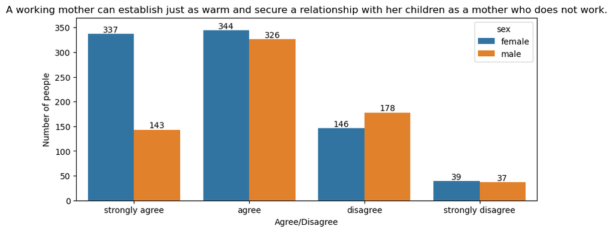

```python
gss_clean_plot = gss_clean.groupby(['sex', 'relationship']).size()
gss_clean_plot = gss_clean_plot.reset_index()
gss_clean_plot = gss_clean_plot.rename({0:'count'}, axis=1)

plt.figure(figsize=(10, 4))
myplt = sns.barplot(x='relationship', y='count', hue='sex', data=gss_clean_plot)
# set the y limit
plt.ylim([0,370])
plt.ylabel('Number of people')
plt.xlabel('Agree/Disagree')
plt.title('A working mother can establish just as warm and secure a relationship with her children as a mother who does not work.')
for rect in myplt.patches:
    xcoor = rect.get_x() + .5*rect.get_width()
    ycoor = rect.get_height()
    plt.text(xcoor, ycoor, str(int(ycoor)),
             horizontalalignment='center',
             verticalalignment='bottom',
             fontsize=10)
```

**Now with the `plot()` method with horizontal bars**

```python
xtab = pd.crosstab(gss_clean.relationship, gss_clean.sex)
```

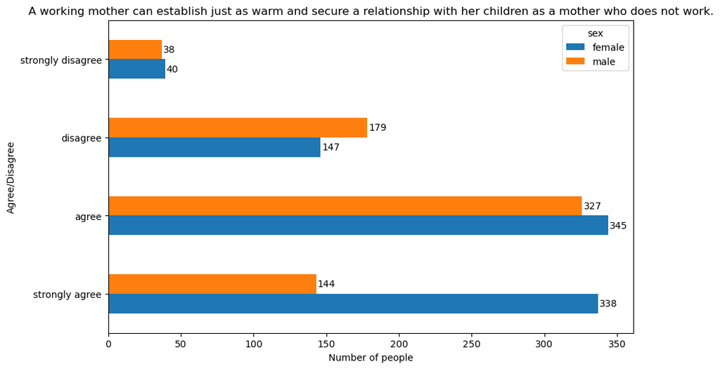

```python
myplot = xtab.plot(kind='barh', figsize = [10,6])
plt.ylabel('Agree/Disagree')
plt.xlabel('Number of people')
plt.title('A working mother can establish just as warm and secure a relationship with her children as a mother who does not work.')
for rect in myplot.patches:
    ycoor = rect.get_y() + .5*rect.get_height()
    xcoor = rect.get_width() + 1
    plt.text(xcoor, ycoor, str(int(xcoor)),
             horizontalalignment='left',
             verticalalignment='center',
             fontsize=10)
```

### Part c

Create a visualization with

- nine barplots, arranged in a 3x3 grid.
- The barplots should refer to each of the nine categories of `region`,
- and each barplot should be given a label that contains the name of the region.
- Within each barplot, list the categories of `relationship`,
- and display horizontal bars.

Only one figure is required. Use `seaborn`, `matplotlib`, and `.plot()` as you see fit. [2 points]

**I think the `seaborn FacetGrid` should work nicely for this problem**

```python
# gss_clean turn region into a categorical variable
gss_clean['region'] = pd.Categorical(gss_clean.region.astype('category'))
```

```python
gss_clean['region'].unique().to_list()
```

```
['new england',
 'middle atlantic',
 'pacific',
 'e. nor. central',
 'south atlantic',
 'w. sou. central',
 'mountain',
 'w. nor. central',
 'e. sou. central']
```

```python
gss_clean['region'] = pd.Categorical(gss_clean.region.astype('category'),
                      categories=["w. nor. central","e. nor. central","new england","pacific","mountain","middle atlantic","w. sou. central","e. sou. central","south atlantic"],
                      ordered=True)
```

```python
gss_plot = gss_clean.groupby(['region','relationship']).size().reset_index()
gss_plot = gss_plot.rename({0:'count'}, axis=1)
```

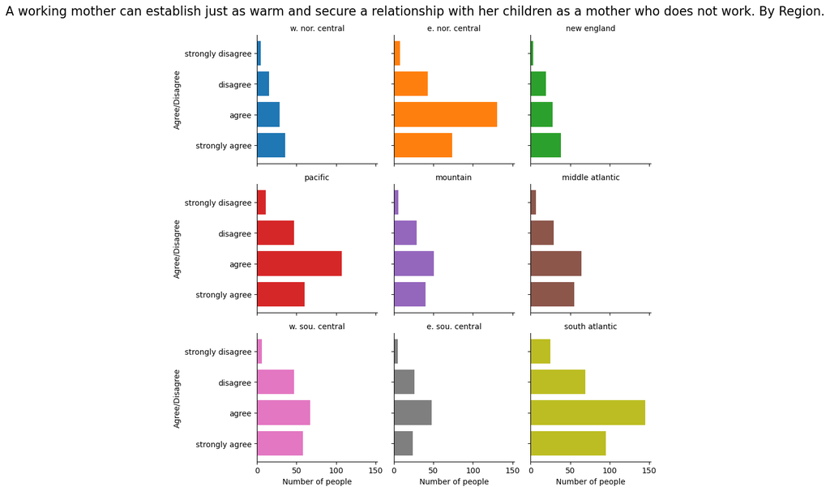

```python
g = sns.FacetGrid(gss_plot, col = 'region', hue = 'region', col_wrap=3, height=3, aspect=1)
g.map(plt.barh, 'relationship', 'count')
g.set_titles('{col_name}')
g.set_axis_labels('Number of people', 'Agree/Disagree')
g.fig.subplots_adjust(top=.92)
g.fig.suptitle('A working mother can establish just as warm and secure a relationship with her children as a mother who does not work. By Region.', fontsize=16)
```

## Problem 3

Write code that exactly replicates the following figures, including all aesthetic choices. **Don't worry, however, about making the size of the figures exactly the same as that varies from browser to browser.** All of the following figures are generated by a primary graphing function from `seaborn`.

### Part a

Replicate the following figure:

[figure not shown]

[Hint: the values of occuptational prestige and socioeconomic status are the means of `job_prestige` and `socioeconomic_index` within years of `education`. Note that values of `education` less than 8 are excluded.] [2 points]

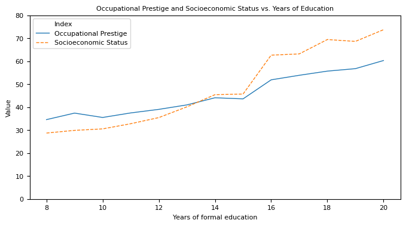

```python
gss_p3a = gss_clean.query('education > = 8')

plt.figure(figsize=(8, 4))
sns.lineplot(data=gss_p3a, x='education', y='job_prestige', linewidth=1., errorbar=None, label='Occupational Prestige')
sns.lineplot(data=gss_p3a, x='education', y='socioeconomic_index', linewidth=1., errorbar=None, label='Socioeconomic Status', linestyle='dashed')
plt.ylim([0,80])
plt.ylabel('Value', fontsize=8)
plt.xlabel('Years of formal education', fontsize=8)
plt.xticks(fontsize=8)
plt.yticks(fontsize=8)
l = plt.legend(fontsize=8, loc='upper left', title='Index', title_fontsize=8)
l.get_title().set_position((-30, 0))
plt.title('Occupational Prestige and Socioeconomic Status vs. Years of Education', fontsize=8)
```

### Part b

Replicate the following figure:

[figure not shown]

[Hint: to match the color scheme, you will need to set `center=0`.] [2 points]

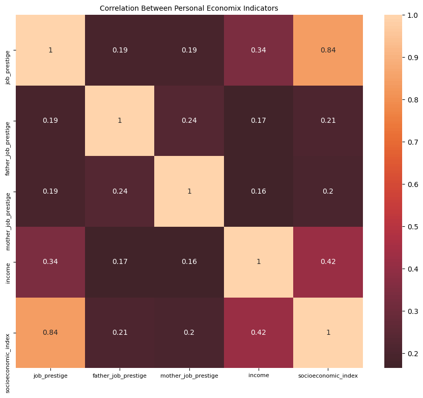

```python
gss_p3b = gss_clean[['job_prestige','father_job_prestige','mother_job_prestige','income','socioeconomic_index']]
# Draw a heatmap with the numeric values in each cell
f, ax = plt.subplots(figsize=(11, 9))
sns.heatmap(gss_p3b.corr(), annot=True, linewidths=.0, ax=ax, center=0.)
plt.yticks(rotation = 90, fontsize=8)

for label in ax.get_yticklabels(minor=False):
    print(label) # printing the labels to make sure I understand what I am doing
    label.set_verticalalignment('top')

plt.xticks(fontsize=8)
ax.tick_params(axis='x', labelrotation = 0)
plt.title('Correlation Between Personal Economix Indicators', fontsize=10)
```

### Part c

Replicate the following figure:

[figure not shown]

[Hint: The individual plots inside the grid have `height=4` and `aspect=1`, and to include the overall title I used

```
g.fig.subplots_adjust(top=.95)
g.fig.suptitle('Income vs. Prestige by Education', fontsize=16)
```

You will first need to create a version of `education` that collapses values from 0 to 10 to "10 years or fewer" and collapses values from 17 to 20 to "More than 16 years". You can use `.map()`, `.replace()`, or `pd.cut()` to do that.] [3 points]

```python
df_p3_c  = gss_clean.copy()
df_p3_c['education_cut'] = pd.cut(df_p3_c['education'], bins=[0, 10, 11, 12,13,14,15,16,21], labels=['10 years or fewer', '11 years', '12 years','13 years','14 years','15 years','16 years','More than 16 years'])
# turn education_cut into a categorical variable
df_p3_c['education_cut'] = pd.Categorical(df_p3_c.education_cut.astype('category'),
                                          categories=['10 years or fewer',"11 years","12 years","13 years","14 years","15 years","16 years","More than 16 years"],
                      ordered=True)
```

```python
df_p3_c['education_cut'].unique()
```

```
['14 years', '10 years or fewer', '16 years', 'More than 16 years', '13 years', '12 years', '15 years', '11 years', NaN]
Categories (8, object): ['10 years or fewer' < '11 years' < '12 years' < '13 years' < '14 years' < '15 years' < '16 years' < 'More than 16 years']
```

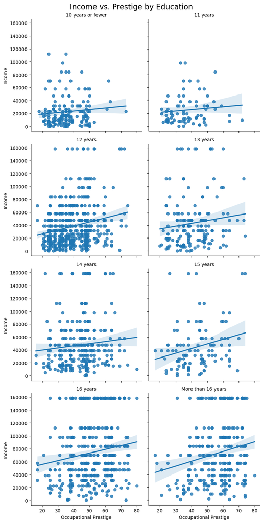

```python
# set the figure size
g = sns.FacetGrid(df_p3_c, col = 'education_cut', col_wrap=2,
                 height=4, aspect=1)
g.map(sns.regplot, 'job_prestige', 'income')
g.set_titles('{col_name}')
g.set_axis_labels('Occupational Prestige', 'Income')
g.fig.subplots_adjust(top=.95)
g.fig.suptitle('Income vs. Prestige by Education', fontsize=16)
#make the figure size 90% as big as the default
g.fig.set_size_inches(8, 16)
```

## Problem 4

There is a consistent finding that in the United States that [women get paid only 80% of what men get paid](https://nwlc.org/issue/equal-pay-and-the-wage-gap/). Other research however finds that the gap is much smaller when comparing [men and women who hold the same job](https://www.politifact.com/factchecks/2018/apr/13/tina-smith/do-women-get-only-80-percent-pay-men-do-same-job/). In this problem you will use the GSS data to investigate the following questions:

1. Do men have higher incomes than women?
2. If there is a difference, is this difference due to the fact that men have jobs with higher occupational prestige than women?

You may use any kind of data visualization and you may use multiple visualizations to find an answer to these questions. In order to receive credit for this problem, you must write in text what parts of your visualizations are important and what we should learn from the visualizations to answer the questions. Please consider the entire distributions of income and occupational prestige, not just the means or medians. [4 points]

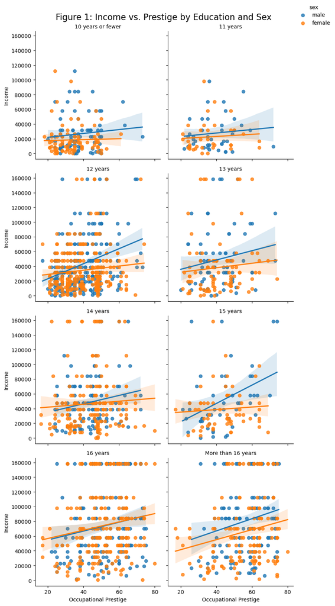

```python
# set the figure size
g = sns.FacetGrid(df_p3_c, col = 'education_cut', hue='sex', col_wrap=2,
                 height=4, aspect=1)
g.map(sns.regplot, 'job_prestige', 'income')
# adjust the alpha of the points in the subplots
g.set_titles('{col_name}')
g.set_axis_labels('Occupational Prestige', 'Income')
g.fig.subplots_adjust(top=.95)
g.fig.suptitle('Figure 1: Income vs. Prestige by Education and Sex', fontsize=16)
#make the figure size 90% as big as the default
g.fig.set_size_inches(8, 16)
# add the legend to the upper right corner
g.add_legend(loc='upper right')
```